# Case Study 2: IMDB – Binary Classification of Movie Reviews

In this case study, our objective is to classify movie reviews as positive or negative. This is a classic *binary classification*, which aims to predict one of two classes. To predict whether a review is positive or negative, we will use the text of the movie review.

Throughout this case study you will learn a few new concepts:

- Vectorizing text with one-hot encoding
- How binary crossentropy works
- How to customize the gradient descent optimizer along with the loss and metric functions
- What weight regularization is and how to incorporate it

# The IMDB dataset

slides: - IMDB

Our data consists of 50,000 movie reviews from [IMDB](https://www.imdb.com/). First, let’s grab our data and unpack them into training vs test and features vs labels.

```r
imdb <- dataset_imdb(num_words = 10000)
c(c(train_data, train_labels), c(test_data, test_labels)) %<-% imdb

length(train_data)   # 25K reviews in our training data
```

```
[1] 25000
```

```r
length(test_data)    # 25K reviews in our test data
```

```
[1] 25000
```

# Understanding our data

slides: - illustrate shape of data - illustrate review

The reviews have been preprocessed, and each review is encoded as a sequence of word indexes (integers). For convenience, words are indexed by overall frequency in the dataset. For example, the integer “14” encodes the 14th most frequent word in the data.

```r
train_data[[1]]
```

```
  [1]    1   14   22   16   43  530  973 1622 1385   65  458 4468   66 3941    4  173   36  256    5   25
 [21]  100   43  838  112   50  670    2    9   35  480  284    5  150    4  172  112  167    2  336  385
 [41]   39    4  172 4536 1111   17  546   38   13  447    4  192   50   16    6  147 2025   19   14   22
 [61]    4 1920 4613  469    4   22   71   87   12   16   43  530   38   76   15   13 1247    4   22   17
 [81]  515   17   12   16  626   18    2    5   62  386   12    8  316    8  106    5    4 2223 5244   16
[101]  480   66 3785   33    4  130   12   16   38  619    5   25  124   51   36  135   48   25 1415   33
[121]    6   22   12  215   28   77   52    5   14  407   16   82    2    8    4  107  117 5952   15  256
[141]    4    2    7 3766    5  723   36   71   43  530  476   26  400  317   46    7    4    2 1029   13
[161]  104   88    4  381   15  297   98   32 2071   56   26  141    6  194 7486   18    4  226   22   21
[181]  134  476   26  480    5  144   30 5535   18   51   36   28  224   92   25  104    4  226   65   16
[201]   38 1334   88   12   16  283    5   16 4472  113  103   32   15   16 5345   19  178   32
```

We can map the integer values back the original word index. The integer number corresponds to the position in the word count list and the name of the vector is the actual word.

```r
word_index <- dataset_imdb_word_index() %>%
  unlist() %>%
  sort() %>%
  names()

# The indices are offset by 3 since 0, 1, and 2 are reserved for "padding",
# "start of sequence", and "unknown"
train_data[[1]] %>%
  map_chr(~ ifelse(.x >= 3, word_index[.x - 3], "?")) %>%
  cat()
```

```
? this film was just brilliant casting location scenery story direction everyone's really suited the part they played and you could just imagine being there robert ? is an amazing actor and now the same being director ? father came from the same scottish island as myself so i loved the fact there wa…
```

Our response variable is just a vector of 1s (positive reviews) and 0s (negative reviews).

```r
str(train_labels)

# our labels are equally balanced between positive (1s) and negative (0s)
# reviews
table(train_labels)
```

# Preparing the features

slides: - vectorization - one-hot encoding - importance of data being small, typically btwn 0-1 - illustrate how the IMDB data compares to MNIST

All inputs and response values in a neural network must be tensors of either floating-point or integer data. Moreover, our feature values should not be relatively large compared to the randomized initial weights *and* all our features should take values in roughtly the same range.

Consequently, we need to *vectorize* our data into a format conducive to neural networks. For this data set, we’ll transform our list of article reviews to a 2D tensor of 0s and 1s representing if the word was used (aka one-hot encode).

```r
# number of unique words will be the number of features
n_features <- c(train_data, test_data) %>%
  unlist() %>%
  max()

# function to create 2D tensor (aka matrix)
vectorize_sequences <- function(sequences, dimension = n_features) {
  # Create a matrix of 0s
  results <- matrix(0, nrow = length(sequences), ncol = dimension)

  # Populate the matrix with 1s
  for (i in seq_along(sequences))
    results[i, sequences[[i]]] <- 1
  results
}

# apply to training and test data
train_data_vec <- vectorize_sequences(train_data)
test_data_vec <- vectorize_sequences(test_data)
```

# Preparing the labels

In contrast MNIST, the labels of a binary classification will just be one value, 0 or 1, so we will just make the integer vector numeric.

```r
# prepare training labels
train_labels <- as.numeric(train_labels)
str(train_labels)

# prepare test labels
test_labels <- as.numeric(test_labels)
str(test_labels)
```

# Initial model

Slides: - Discuss what the loss function means - Tips regarding batch size and epochs

## Define the network

Since we are performing binary classification, our output activation function will be the *sigmoid activation function*.

```r
network <- keras_model_sequential() %>%
  layer_dense(units = 16, activation = "relu", input_shape = n_features) %>%
  layer_dense(units = 16, activation = "relu") %>%
  layer_dense(units = 1, activation = "sigmoid")
```

## View a summary of the network

```r
summary(network)
```

```
Model: "sequential_4"
_________________________________________________________________________________________________________
Layer (type)                                   Output Shape                              Param #
=========================================================================================================
dense_12 (Dense)                               (None, 16)                                160000
_________________________________________________________________________________________________________
dense_13 (Dense)                               (None, 16)                                272
_________________________________________________________________________________________________________
dense_14 (Dense)                               (None, 1)                                 17
=========================================================================================================
Total params: 160,289
Trainable params: 160,289
Non-trainable params: 0
_________________________________________________________________________________________________________
```

## Compile

We’re going to use *binary crossentropy* since we only have two possible classes.

```r
network %>% compile(
  optimizer = "rmsprop",
  loss = "binary_crossentropy",
  metrics = c("accuracy")
)
```

## Train our model

Now let’s train our network for 20 epochs:

```r
history <- network %>% fit(
  train_data_vec,
  train_labels,
  epochs = 20,
  batch_size = 512,
  validation_split = 0.2
)
```

```r
history
```

[output not shown]

# Customizing compilation

- show how we can use optimizer, loss, and metric functions
- demo a custom built metric??
- takeaway
  - we can customize if necessary
  - RMSProp and default learning rate is typically good enough

Sometimes you may want to configure the parameters of your optimizer or pass a custom loss (or metric) function. We can do so by passing optimizer, loss, and/or metric functions to the `compile` arguments.

- optimizers all start with `optimizer_` (https://keras.rstudio.com/reference/index.html#section-optimizers)
- losses all start with `loss_` (https://keras.rstudio.com/reference/index.html#section-losses)
- metricss all start with `metric_` (https://keras.rstudio.com/reference/index.html#section-metrics)

```r
network <- keras_model_sequential() %>%
  layer_dense(units = 16, activation = "relu", input_shape = n_features) %>%
  layer_dense(units = 16, activation = "relu") %>%
  layer_dense(units = 1, activation = "sigmoid")

# create metric using backend tensor functions
metric_mean_pred <- custom_metric("mean_pred", function(y_true, y_pred) {
  k_mean(y_pred)
})

network %>% compile(
  optimizer = optimizer_rmsprop(lr = 0.0005), # default learning rate = 0.001
  loss = loss_binary_crossentropy,
  metrics = c("accuracy", metric_mean_pred)
)

history <- network %>% fit(
  train_data_vec,
  train_labels,
  epochs = 20,
  batch_size = 512,
  validation_split = 0.2
)
```

## YOUR TURN

1. Test out different gradient descent optimizers (i.e. Adagrad, Adam)
2. Test out different learning rates in the optimizers

```r
network <- keras_model_sequential() %>%
  layer_dense(units = 16, activation = "relu", input_shape = n_features) %>%
  layer_dense(units = 16, activation = "relu") %>%
  layer_dense(units = 1, activation = "sigmoid")

# create metric using backend tensor functions
metric_mean_pred <- custom_metric("mean_pred", function(y_true, y_pred) {
  k_mean(y_pred)
})

network %>% compile(
  optimizer = ______,
  loss = "binary_crossentropy",
  metrics = c("accuracy")
)

history <- network %>% fit(
  train_data_vec,
  train_labels,
  epochs = 20,
  batch_size = 512,
  validation_split = 0.2
)
```

# Validation procedures

- discuss importance of holding out the test
- show how you can also supply a validation set
- takeaway
  - we can supply a validation set two different ways
  - if data is ordered then should randomize
  - discuss when cross-validation is required and how to incorporate

So far we have performed model validation by using `validation_split`. Sometimes this may not be appropriate. `validation_split` selects the last XX% samples in the x and y data provided. So, if our data is ordered than this could skew our results.

An alternative is to create our own validation data and supply it via `validation_data`. First we extract our own train vs. validation data sets:

```r
set.seed(123)
index <- sample(1:nrow(train_data_vec), size = floor(nrow(train_data_vec) * 0.8))

x_train <- train_data_vec[index,]
y_train <- train_labels[index]

x_val <- train_data_vec[-index,]
y_val <- train_labels[-index]

length(y_train)
```

```
[1] 20000
```

```r
length(y_val)
```

```
[1] 5000
```

Now, we can supply our validation data to `validation_data`:

```r
network <- keras_model_sequential() %>%
  layer_dense(units = 16, activation = "relu", input_shape = n_features) %>%
  layer_dense(units = 16, activation = "relu") %>%
  layer_dense(units = 1, activation = "sigmoid")

network %>% compile(
  optimizer = "rmsprop",
  loss = "binary_crossentropy",
  metrics = c("accuracy")
)

history <- network %>% fit(
  x_train,                             # supply our new training features data
  y_train,                             # supply our new training labels data
  epochs = 20,
  batch_size = 512,
  validation_data = list(x_val, y_val) # supply our validation data
  )
```

As the number of observations in our data increases, variance in our loss score will decrease. However, we do not always have the option to just go out and get more data. So, if we want to gain a more accurate understanding of the loss score and its variance we can perform *k-fold cross validation*.

```r
# number of folds
k <- 5

# randomize data before making folds
set.seed(123)
indices <- sample(1:nrow(train_data_vec))

# divide the ordered indices into k intervals, labelled 1:k.
folds <- cut(indices, breaks = k, labels = FALSE)
str(folds)
```

```
 int [1:25000] 4 4 1 1 1 3 1 2 4 1 ...
```

```r
# create a data frame to store results
results <- data.frame()

for (i in seq_len(k)) {
  cat("processing fold #", i, "\n")

  # Prepare the training and validation data for each fold
  val_indices <- which(folds == i, arr.ind = TRUE)

  # validation set: the ith partition
  x_val <- train_data_vec[val_indices,]
  y_val <- train_labels[val_indices]

  # Training set: all other partitions
  x_train <- train_data_vec[-val_indices,]
  y_train <- train_labels[-val_indices]

  # Create our model blueprint
  network <- keras_model_sequential() %>%
    layer_dense(units = 16, activation = "relu", input_shape = n_features) %>%
    layer_dense(units = 16, activation = "relu") %>%
    layer_dense(units = 1, activation = "sigmoid") %>%
    compile(
      optimizer = "rmsprop",
      loss = "binary_crossentropy",
      metrics = c("accuracy")
      )

  # Train our model with and supply train / validation data
  history <- network %>% fit(
    x_train,
    y_train,
    epochs = 20,
    batch_size = 512,
    validation_data = list(x_val, y_val),
    verbose = FALSE
    )

  # Extract the performance data
  model_performance <- as.data.frame(history) %>% mutate(fold = i)
  results <- rbind(results, model_performance)
}
```

```
processing fold # 1
processing fold # 2
processing fold # 3
processing fold # 4
processing fold # 5
```

We can plot the results:

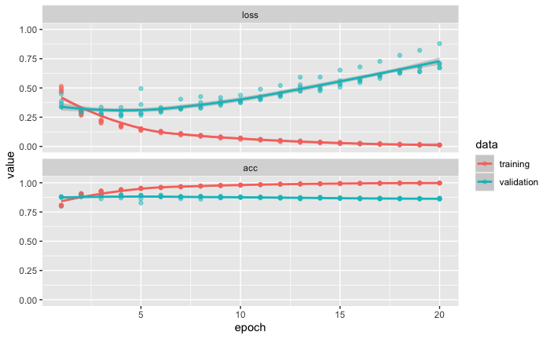

```r
ggplot(results, aes(epoch, value, color = data)) +
  geom_point(alpha = 0.5) +
  geom_smooth() +
  facet_wrap(~ metric, ncol = 1)
```

But if we zoom in on the validation loss we can see the variance that exists:

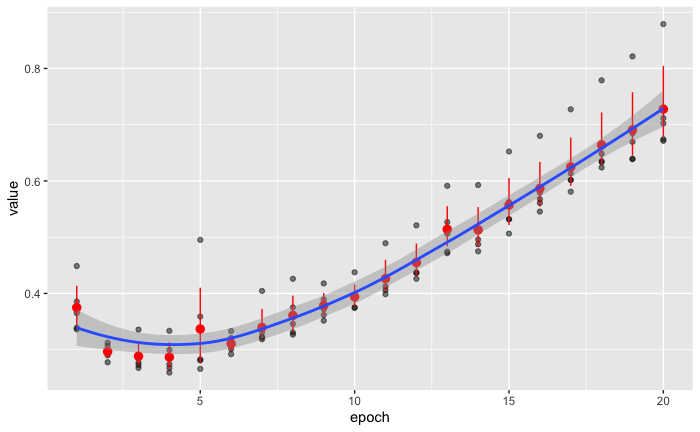

```r
results %>%
  filter(data == 'validation', metric == 'loss') %>%
  ggplot(aes(epoch, value)) +
  geom_point(alpha = 0.5) +
  stat_summary(fun.data = "mean_cl_boot", colour = "red") +
  geom_smooth()
```

```r
# which epic has lowest avg loss
best_epoc <- results %>%
  group_by(epoch) %>%
  filter(metric == 'loss', data == 'validation') %>%
  summarise(avg_loss = mean(value),
            std_loss = sd(value)) %>%
  top_n(-1, wt = avg_loss)

best_epoc
```

| epoch | avg_loss | std_loss |
| --- | --- | --- |
| 4 | 0.2868003 | 0.03014803 |

If we re-train our model with all the training data and use the best epoch, we should see similar results within reason when scoring on new data:

```r
network <- keras_model_sequential() %>%
  layer_dense(units = 16, activation = "relu", input_shape = n_features) %>%
  layer_dense(units = 16, activation = "relu") %>%
  layer_dense(units = 1, activation = "sigmoid") %>%
  compile(
    optimizer = "rmsprop",
    loss = "binary_crossentropy",
    metrics = c("accuracy")
  )

history <- network %>% fit(
  train_data_vec,
  train_labels,
  epochs = best_epoc$epoch,
  batch_size = 512
  )

network %>% evaluate(test_data_vec, test_labels)
```

[output not shown]